# プロジェクト演習中間報告

# プロジェクト演習中間報告

hrkr

2018-12-12

# プロジェクト演習中間報告

## 進捗状況

- 用いるデータ
  - 株価
- 時系列データ解析として以下のモデルを用いた株価予測
  - 自己回帰モデル
  - （移動平均モデル）
  - （自己回帰移動平均モデル）

## 用いる株価データ

- 日産の株価データのうち調整後終値を利用

```r
(df <- read_csv("../data-raw/nm2018.csv"))
```

| date | open | high | low | close | turnover | adjustedClose |
| --- | --- | --- | --- | --- | --- | --- |
| 2018/1/4 | 1130.0 | 1136.5 | 1128.0 | 1134.0 | 15474800 | 1134.0 |
| 2018/1/5 | 1138.0 | 1149.5 | 1137.0 | 1149.0 | 17994900 | 1149.0 |
| 2018/1/9 | 1154.0 | 1167.5 | 1153.5 | 1156.5 | 20405500 | 1156.5 |
| 2018/1/10 | 1156.5 | 1162.0 | 1155.0 | 1156.5 | 13119400 | 1156.5 |
| 2018/1/11 | 1150.0 | 1158.5 | 1150.0 | 1157.5 | 12324500 | 1157.5 |
| 2018/1/12 | 1155.0 | 1157.0 | 1146.5 | 1148.5 | 13584700 | 1148.5 |
| 2018/1/15 | 1152.0 | 1159.5 | 1150.0 | 1150.0 | 9583800 | 1150.0 |
| 2018/1/16 | 1149.0 | 1157.0 | 1148.0 | 1154.5 | 9263900 | 1154.5 |
| 2018/1/17 | 1151.5 | 1152.5 | 1147.0 | 1149.5 | 12801100 | 1149.5 |
| 2018/1/18 | 1160.0 | 1162.0 | 1143.5 | 1145.5 | 19085000 | 1145.5 |

[output cut: 211 more lines]

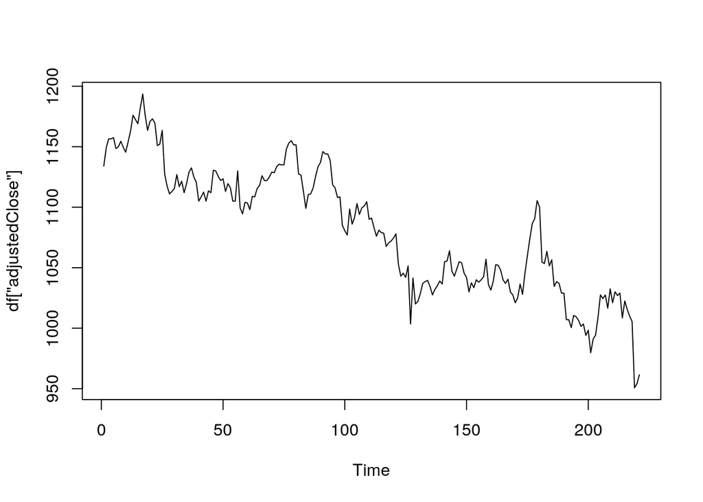

```r
ts.plot(df["adjustedClose"])
```

## 自己回帰モデルによる株価予測

- 自己回帰モデル
  $$X_t=c+\sum_{i=1}^{p}\phi_iX_{t-i}+\epsilon_t$$
  （$c$は定数項，$\epsilon_t$は白色雑音，$\phi_i$はモデルのパラメータ）
- このモデルを用いて1期（1日）先予測を10期分行い真値と比較

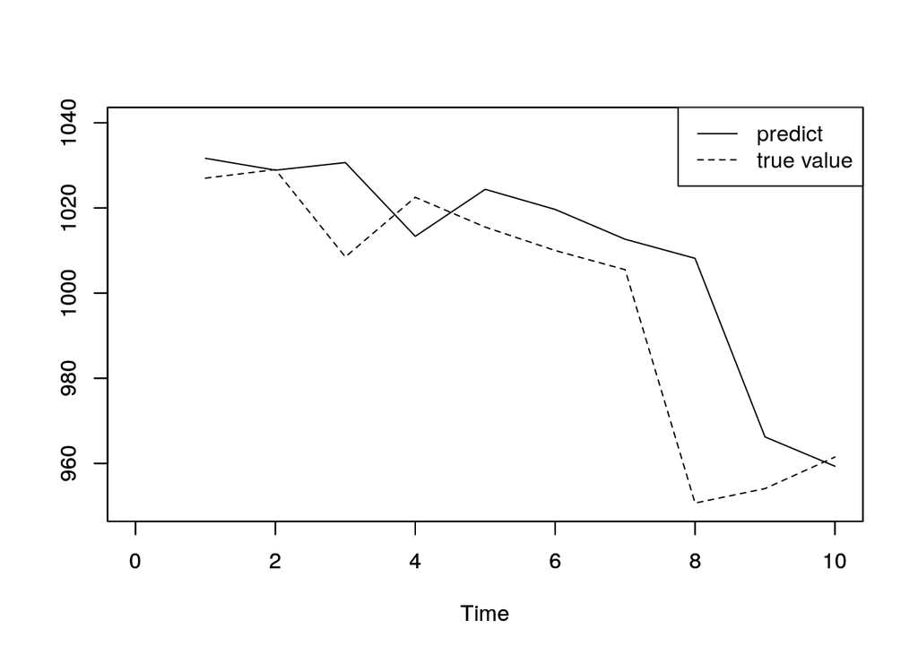

```r
df <- read.csv("../data-raw/nm2018.csv",
               header = T,
               row.names = 1)
adjclose_data <- as.ts(df["adjustedClose"])
j <- 1
ar_predict_result <- matrix()
for(i in 211:220) {
  training_data <- adjclose_data[1:i]
  ar_data_adjclose <- ar(training_data)
  ar_predict_adjclose <- predict(ar_data_adjclose, ahead = 1)
  ar_predict_result[j] <- ar_predict_adjclose$pred[1]
  j <- j + 1
}
ts.plot(
  as.ts(ar_predict_result),
  xlim = c(0, 10),
  ylim = c(950, 1040),
  ann = FALSE
  )
par(new = T)
ts.plot(
  as.ts(adjclose_data[212:221]),
  xlim = c(0, 10),
  ylim = c(950, 1040),
  lty = "dashed",
  ann = F
  )
legend("topright",
       lty = 1:2,
       legend = c("predict", "true value"))
```

## 今後の予定

- 移動平均や自己回帰移動平均を用いて予測
- R Markdownでレポートにまとめる